# LI-6800 和 LI-6400 光合数据分析指南 - 19 LI-6800 JIP test 分析

LI-6800 能够直接提供基本的叶绿素荧光参数，其他参数均可通过这些基本的参数进行计算，计算也较简单，在此不赘述，需要注意的是快相荧光部分的数据，因为分析 ojip 数据的模型有很多，多数情况下都需要大量的计算，在此我们先将其中较为简单的 jip test 数据分析进行介绍。

**提示**

如果使用 LI-6800 的快相荧光做 OJIP 曲线的分析，建议使用连续光荧光信号的数据（带 dc 的函数），对于绝大多数参数来讲，使用调制光还是连续光并无差异，但是对于曲线面积的计算来讲，连续信号灯数据点要明显更多，这对计算有利。而且对于一些荧光信号偏低的样品，连续光信号可以明显提升信噪比（我使用的示例数据面积计算结果基本相同，这是因为我测量时信噪比明显比较高的原因）。

## 19.1 jip test 的实现

分析依赖于我写的 `jiptest` 软件包，去年冬天（2020.11）我修改了一次，其中我希望大改的是求曲线下部面积的部分，**因为曲线形状不规则，需要用到积分，我用的现成的软件包，而且印象里求面积没有使用标准化后的数据来进行计算，所以不太合适，这个我争取近期找时间来解决一下，这里先立一个 flag，**安装可以按照下面的方式：

```r
remotes::install_github("zhujiedong/jiptest")
# 或
remotes::install_git('https://gitee.com/zhu_jie_dong/jiptest')
```

## 19.2 `read_files` 及 `read_dcfiles` 函数

`read_files` 用于批量读取所有调制光测量数据，方便用于其他的数据分析。**函数要求所有数据必须是 `xlsx` 格式，并且所有测量数据都保存在同一文件夹内。**，如有其他文件或测量数据则会报错。 `read_dcfiles` 用于批量读取所有连续光测量数据，其他选项与 `read_dcfiles` 相同。例如在了 data文件夹下的 ojip 文件夹内，有五个数据文件。

函数仅有一个参数，即保存数据文件夹的路径，使用如下：

读取调制光测量数据：

```r
library(jiptest)
jip_data<- read_files("data/ojip")
```

读取连续光数据：

```r
jip_dcdata <- read_dcfiles("data/ojip")
```

Table 19.1: jiptest 批量导入数据后的样式

| SECS | MILLI_SEC | FLUOR | NORM_FLUOR | SOURCE |
| --- | --- | --- | --- | --- |
| 6.10e-06 | 0.0060797 | 621 | 0.0005027 | INDUCTION-4188-20201116-10_53_39 |
| 1.01e-05 | 0.0101328 | 620 | 0.0000000 | INDUCTION-4188-20201116-10_53_39 |
| 1.42e-05 | 0.0141859 | 649 | 0.0145781 | INDUCTION-4188-20201116-10_53_39 |
| 1.80e-05 | 0.0180006 | 629 | 0.0045242 | INDUCTION-4188-20201116-10_53_39 |
| 2.21e-05 | 0.0220537 | 674 | 0.0271455 | INDUCTION-4188-20201116-10_53_39 |
| 2.61e-05 | 0.0261068 | 736 | 0.0583126 | INDUCTION-4188-20201116-10_53_39 |

Table 19.2: jiptest DC 数据批量导入数据后的样式

| SECS | MILLI_SEC | FLUOR | NORM_FLUOR | SOURCE |
| --- | --- | --- | --- | --- |
| 6.10e-06 | 0.0060797 | 98161 | 0.0000000 | INDUCTION-4188-20201116-10_53_39 |
| 1.01e-05 | 0.0101328 | 100331 | 0.0071347 | INDUCTION-4188-20201116-10_53_39 |
| 1.42e-05 | 0.0141859 | 102577 | 0.0145193 | INDUCTION-4188-20201116-10_53_39 |
| 1.80e-05 | 0.0180006 | 104849 | 0.0219894 | INDUCTION-4188-20201116-10_53_39 |
| 2.21e-05 | 0.0220537 | 107214 | 0.0297652 | INDUCTION-4188-20201116-10_53_39 |
| 2.61e-05 | 0.0261068 | 109624 | 0.0376890 | INDUCTION-4188-20201116-10_53_39 |

**注意**

NORM_FLUOR 是标准化后的荧光信号数据，其中标准化采用的方式是 Stirbet and Govindjee (2012) 所采用的：$F = \frac{F_t - F_o}{F_m - F_o}$，而曲线上部的面积则采用 Stirbet and Govindjee (2011) 的方式进行标准化，以方便不同叶片之间的比较，具体为 $area = \frac{area}{F_m - F_o}$

## 19.3 `jip_test` 及 `jip_dctest` 函数

`jiptest` 是 jiptest 的核心函数，用于所有数据的 `jiptest` 分析，函数仅包一个参数，测量数据的保存文件夹路径。 `jip_dctest` 与 `jip_test` 相似，用于连续光测量数据的分析。

```r
actest <- jip_test("data/ojip")
```

```r
dctest <- jip_dctest("data/ojip")
```

调制光信号的计算参数：

|  | parameters | data_file1 | data_file2 | data_file3 | data_file4 | data_file5 |
| --- | --- | --- | --- | --- | --- | --- |
| 1 | Fo | 620 | 887 | 849 | 981 | 914 |
| 2 | Fm | 2609.28 | 4649.52 | 3714.27 | 4225.24 | 3754.27 |
| 3 | F300 | 1593.2 | 2181.4 | 1798.6 | 2067.8 | 2537.2 |
| 4 | FJ | 1722.9 | 2594.3 | 2104.6 | 2456.8 | 2569 |
| 5 | FI | 2268.95 | 4443.11 | 3547.11 | 4009.22 | 3556.53 |
| 6 | Tfmax | 159.99799936 | 256.016 | 316.016 | 272.016 | 200.016 |
| 7 | Area | 20246.8278185561 | 34884.5847313333 | 27168.9315215597 | 30308.2468891367 | 25661.0103903039 |
| 8 | Fv | 1989.28 | 3762.52 | 2865.27 | 3244.24 | 2840.27 |
| 9 | Vj | 0.554421700313681 | 0.453765029820439 | 0.43821350169443 | 0.45489852785244 | 0.582691082185849 |
| 10 | Mo | 1.95688892463605 | 1.37609899748041 | 1.32566913414792 | 1.33997484773013 | 2.28597985402796 |

[output cut: 24 more lines]

连续光信号计算参数：

|  | parameters | data_file1 | data_file2 | data_file3 | data_file4 | data_file5 |
| --- | --- | --- | --- | --- | --- | --- |
| 1 | Fo | 98161 | 154000 | 133191 | 156664 | 153589 |
| 2 | Fm | 402308 | 713839 | 560610 | 647660 | 584839 |
| 3 | F300 | 246753 | 338091 | 275476.8 | 322859.2 | 388110.4 |
| 4 | FJ | 267827 | 400744 | 320245 | 376885 | 406671 |
| 5 | FI | 349985 | 681505 | 534314 | 614590 | 552253 |
| 6 | Tfmax | 171.99799936 | 276.016 | 300.016 | 288.016 | 212.016 |
| 7 | Area | 3117594.75515898 | 5232714.38168563 | 4030645.374413 | 4615031.84976903 | 3921344.38437033 |
| 8 | Fv | 304147 | 559839 | 427419 | 490996 | 431250 |
| 9 | Vj | 0.557842096091693 | 0.440740998751427 | 0.437636136905472 | 0.448518928871111 | 0.586856811594203 |
| 10 | Mo | 1.95421292993191 | 1.31531386702248 | 1.33158142244495 | 1.35394341298096 | 2.17527095652174 |

[output cut: 24 more lines]

可以看出，对于标准化之后的参数，二者基本一致，原始信号则无法一致，因为连续光信号强度更高（所以数据的比较要在相同的测量光内进行）。 。若需要将数据导出，可以使用相关命令：

```r
write.csv(actest, "d:/data/jip_resluts.csv")
write.csv(dctest, "d:/data/dcjip_resluts.csv")
```

## 19.4 图像查看函数

如果仅仅是简单查看结果，那么我们直接用默认参数就好，作图的数据是之前导入的数据文件：

### 19.4.1 默认图形的方式

1. 默认调制光图形

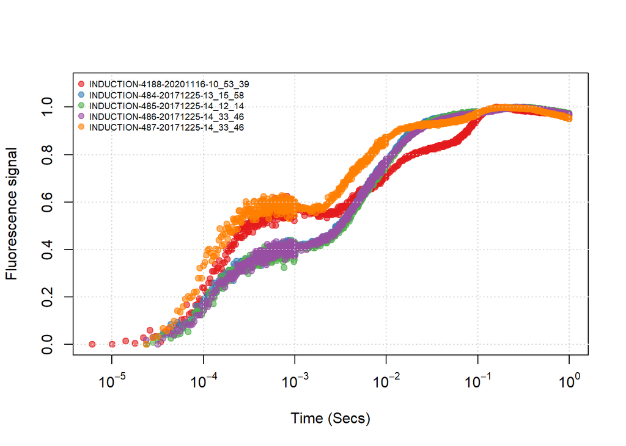

Figure 19.1: 默认调制光图形查看

```r
plot(jip_data)
```

2. 默认连续光图形

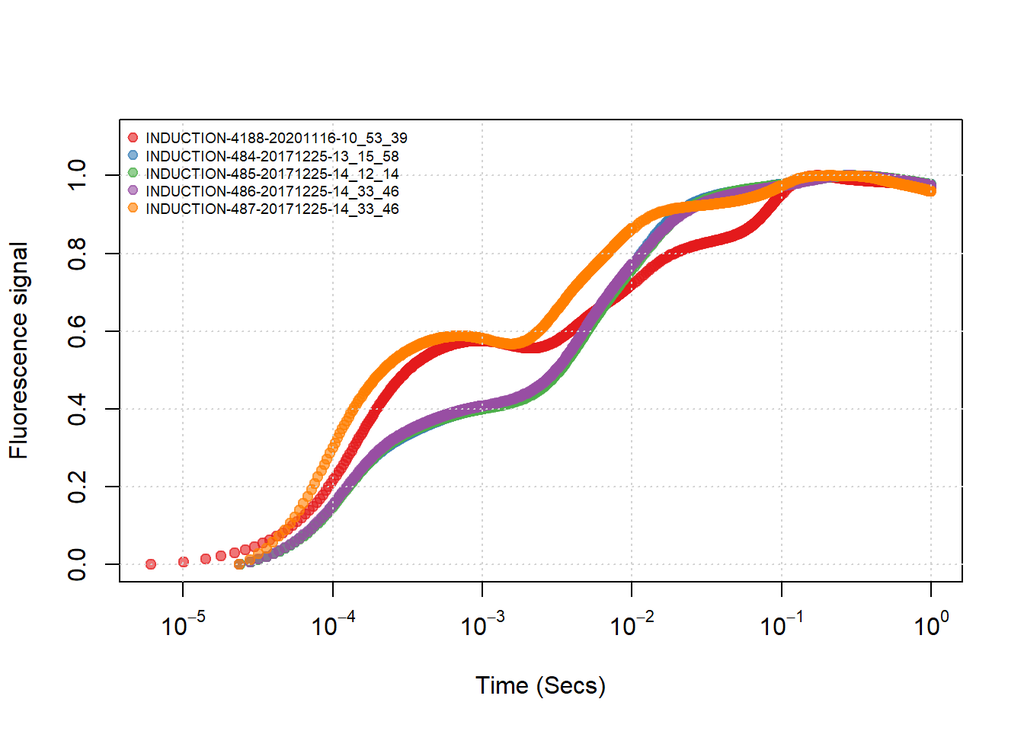

Figure 19.2: 默认连续光图形查看

```r
plot(jip_dcdata)
```

默认图形，仅仅查看结果是可以的，当然有些情况下需要进行调整才方便做展示用。

### 19.4.2 定制化图形的方式

这个是这次改动的重点之一，例如都使用原始信号分别做上面两幅图：

1. 定制调制光图形

这里使用原始荧光信号，然后更改图例颜色等，主要是 `add_leg = FALSE` 不增加默认的图例，以及 `normalized = FALSE` 不使用信号标准化。其他请参考帮助 `?plot.jip`。 我简单写了一下帮助文档，大家应该基本能看明白，我暂时一直没时间详细了写。

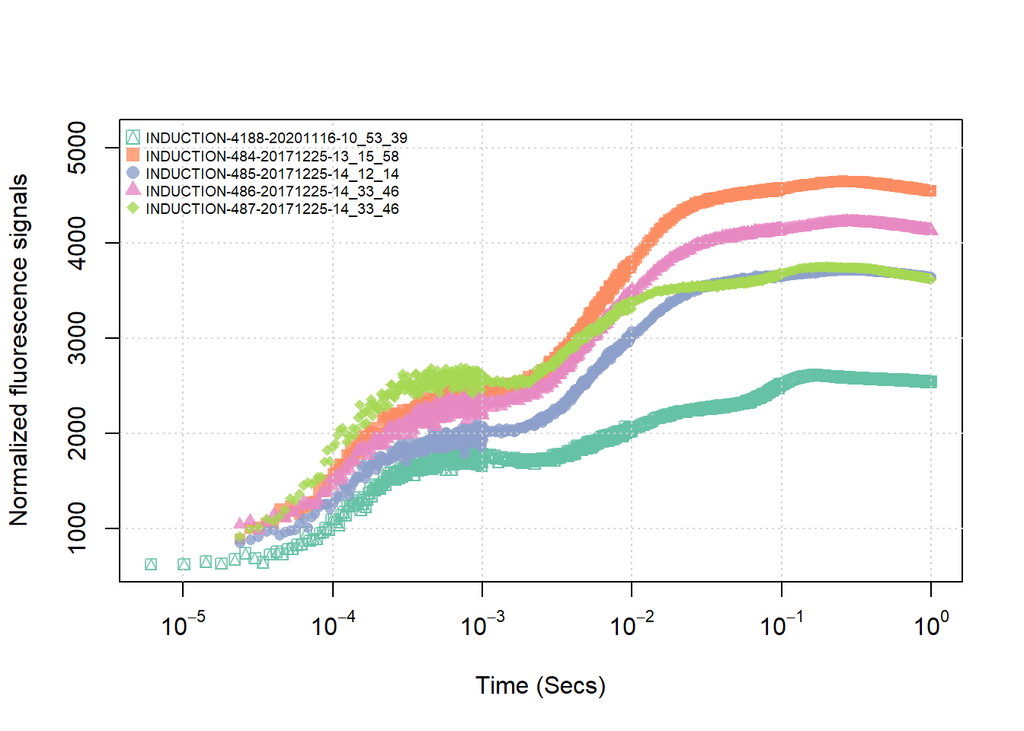

Figure 19.3: 定制调制光图形示例

```r
cls <- palette.colors(n = 5,  "set 2", alpha = 0.8)
plot(
  jip_data,
  ylab = 'Normalized fluorescence signals',
  add_leg = FALSE,
  def_pch = 14:18,
  col = cls,
  main = "Demodulated signals",
  normalized = FALSE
)

legend(
  "topleft",
  unique(jip_data$SOURCE),
  col = cls,
  pch = 14:18,
  cex = 0.6,
  pt.cex = 1.2,
  bty = "n"
)
```

2. 定制连续光图形

连续光图形，例如修改图例的位置以及不显示标准化的数据。

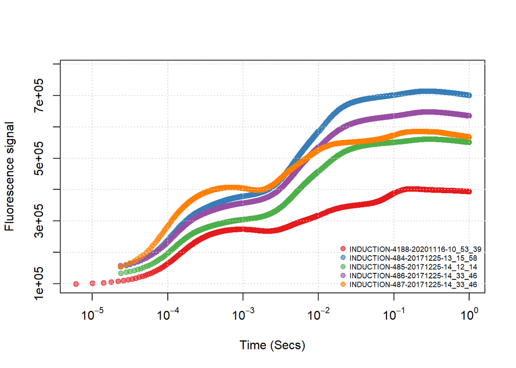

Figure 19.4: 定制连续光图形示例

```r
plot(jip_dcdata, legend_pos = "bottomright", normalized = FALSE)
```

**注意**

关于标准化和非标准化图形差异大的问题，这个比较简单，原始信号比较低的那条线，是不同物种的不同叶片，所以不具备比较价值，我只是程序测试。

**提示**

建议在开始分析数据前，使用作图查看数据质量，若使用调制光数据测量的荧光信号太弱，数据点太散，则可以使用连续光测量信号进行分析，对于归一化的荧光参数，二者几乎无差别。最好的方式当然是在测量时注意荧光信号强度，若基础荧光信号太弱，尝试增加测量叶片的面积，增强荧光信号强度，增大信噪比。

## 19.5 关于 Area 和 Sm 参数计算的说明

具体参数的计算参考了 Tsimilli-Michael (2019) 和 Bussotti et al. (2010)，时间轴的单位是 ms。

在最初的版本中，面积计算原本是用了了一个 三次项样条插值来将数据点拟合为一条曲线，然后对曲线进行计算，前几天有客户询问我计算报错，我只能看出来那是积分错误，但我不知道原因，因为积分的方法我是用的一个叫做 `MASS` 包来处理的，它有一些问题需要处理：

1. `MASS` 有时候改动会导致计算面积不能使用，这个发生过一次，好在改动不是特别大，我修改了之后就能用了。但这就是个问题，依赖别人的软件包，作者我也不认识，人家更新不会通知我，也不会管我能不能用。
2. 样条插值尽管拟合效果不错，但总会因为 J 点和 I 点的拐点导致拟合不佳的情况出现，这样子会带来一定的误差来源。
3. 基本出错我很难定位具体原因。

基于上面这些原因，我使用了下面的方式对面积计算进行修改，当然下面演示的是原理部分，所以我只计算曲线下部面积，反正上部面积是总面积减去下部面积，所以这个不影响最终计算，也能简化我对计算方式的描述。

### 19.5.1 曲线下部面积的计算

计算方法依据这里 [Sotos](https://stackoverflow.com/questions/4954507/calculate-the-area-under-a-curve) 的回答来进行。

基本思路是这样，既然一种积分的方式是将曲线划分为很多个梯形，然后求其总面积。因为我的数据点数量非常大（通常 250 kHz 的调制频率），那么实际上我已经在 1 s 的测量时间内，将曲线划分为 250 kHz - 1 个梯形了（理论上最大值，实际没这么多），那我干脆不用拟合来做曲线，就直接用线连接所有数据点，不久避免了拟合不准确的问题了吗？为简化流程，我将梯形看做矩形，长度使用 2 点滚动平均值来计算，减少误差。因此，下面的内容就是用连续光信号来验证这个观点。

```r
# 使用的软件包
library(zoo)
# 导入依次 OJIP 测量整理好的数据
ac <- read.csv("data/dctest.csv")

# 将数据里的 s 转化为 ms
ac$SECS <- (ac$SECS)*1000

# 使用对数的时间轴
ac$logs <- log(ac$SECS)

# 找到 FO点，因为计算是 OJIP 时间段内的数据
j <- which(ac$FLUOR == max(ac$FLUOR))
# 只选择需要的数据
ac <- ac[1:j,]
# 数据的行数
n <- nrow(ac)

# 使用上面叙述的原理来计算总面积
auc <- with(ac, sum(diff(logs)*rollmean(FLUOR,2)))
auc
```

```
[1] 2543274
```

```r
# 滚动平均值使用的数据，也就是矩形的长
roll <- with(ac, rollmean(FLUOR,2))

# 按照相邻两点多最大值计算最大的误差
auc_max_rect <- with(ac, sum(diff(logs)* FLUOR[2:n]))

# 计算的 sm 参数的最大误差
sm_error <- (auc_max_rect - auc)/(max(ac$FLUOR) - min(ac$FLUOR))
```

这里 Area 误差从数值上看上去不小，但这是没有标准化后的荧光信号强度，实际并不大，而且没有标准化的数据在荧光参数里多数没有比较的价值，我们看一下标准化后的 Sm 参数：

```r
sm_error
```

```
[1] 0.01855341
```

通过图形我们可以直观的观察一下结果：

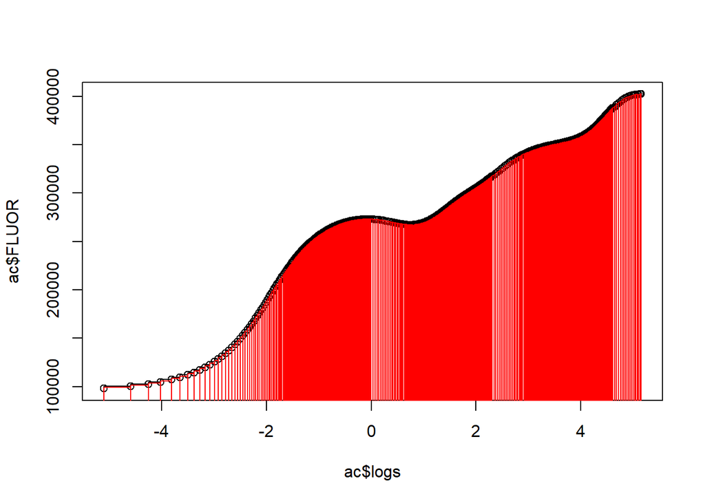

Figure 19.5: 比较使用简化方式计算面积与原来数据点连线之间的差异

```r
#比较原来数据点的线与使用滚动平均值的线的差异
plot(ac$logs, ac$FLUOR)
for (i in (1:(n-1))){
  rect(ac$logs[i], 0, ac$logs[i+1], ac$FLUOR[i+1])
  rect(ac$logs[i], 0, ac$logs[i+1], roll[i], border = 'red')
}
```

Bussotti, Filippo, Rosanna Desotgiu, Martina Pollastrini, and Chiara Cascio. 2010. “The JIP Test: A Tool to Screen the Capacity of Plant Adaptation to Climate Change.” *Scandinavian Journal of Forest Research* 25 (August): 1–8.

Stirbet, Alexandrina, and Govindjee. 2011. “On the Relation Between the Kautsky Effect (Chlorophyll a Fluorescence Induction) and Photosystem II: Basics and Applications of the OJIP Fluorescence Transient.” *Journal of Photochemistry and Photobiology B: Biology*, Special Issue on Recent Progress in the Studies of Structure and Function of Photosystem II, 104 (1): 236–57. https://doi.org/10.1016/j.jphotobiol.2010.12.010.

Stirbet, Alexandrina, and Govindjee. 2012. “Chlorophyll a Fluorescence Induction: A Personal Perspective of the Thermal Phase, the J–I–P Rise.” *Photosynthesis Research* 113 (1): 15–61. https://doi.org/10.1007/s11120-012-9754-5.

Tsimilli-Michael, Merope. 2019. “Revisiting JIP-Test: An Educative Review on Concepts, Assumptions, Approximations, Definitions and Terminology.” *Photosynthetica* 57 (December): 90–107. https://doi.org/10.32615/ps.2019.150.